# Digital Lifestyles

## Introduction

### Background and Motivation

Digital technology has become deeply embedded in daily life, shaping how individuals communicate, work, study and even relax. While increased access to digital devices offers substantial benefits such as improved connectivity, access to information and productivity tools, growing evidence suggests that excessive or poorly managed screen time use may be associated with negative mental health outcomes, including heightened stress, reduced focus and impaired productivity. As screen time continues to rise across age groups and roles, understanding the conditions under which digital engagement becomes harmful or manageable is an increasingly important research concern.

Recent digital well-being research emphasizes that screen time alone may not fully explain variations in mental health outcomes. Instead, lifestyle balance factors like adequate sleep, regular physical activity and effective time management may play a crucial role in shaping how individuals experience and respond to digital demands. Individuals who maintain healthier lifestyle routines may be more resilient to the potential negative effects of prolonged device use, whereas those with poorer lifestyles balance may be more vulnerable.

### Purpose

The purpose of this study is to examine whether lifestyle balance moderates the relationship between screen time and mental health and performance outcomes. Rather than treating screen time as uniformly harmful or beneficial, this study adopts an interaction-based approach to assess whether the strength or direction of screen time’s effect varies depending on individuals sleep patterns, physical activity levels and study habits. By focusing on moderation effects, this research aims to provide a more nuanced understanding of digital well-being that reflects real-world behavioral complexity.

Understanding these conditional relationships may help inform more targeted recommendations for healthy technology use, emphasizing not only limits on screen time but also the importance of balanced daily routines.

## Research Objective

The primary objective of this study is to evaluate whether indicators of lifestyle balance, specifically sleep duration, sleep quality, physical activity frequency and study time, moderate the relationship between daily screen time and mental health and performance outcomes. This objective is addressed through moderation analysis using interaction terms within linear regression models.

### Research Question

**Does lifestyle balance (sleep, physical activity, and study time) moderate the relationship between screen time and mental health?**

To address this question, the study focuses on the following outcomes:

- Stress levels
- Focus scores
- Productivity scores

The study tests whether the effect of screen time of these outcomes differs across levels of lifestyle balance, rather than assuming a constant effect for all individuals.

## Data Description

### Dataset Overview

This study utilizes the *Digital Lifestyle Benchmark Dataset*, a synthetic dataset designed to model realistic relationships between digital behavior patterns and mental well-being outcomes. The dataset contains 3,500 simulated participant records and includes 24 variables spanning demographic characteristics, digital behavior, lifestyle balance indicators and psychological outcomes. Although the data are synthetic and contain no personally identifiable information, the structure and correlations are designed to reflect empirical trends observed in digital well-being and mental health research.

A key feature of the dataset is the inclusion of continuous behavioral and psychological measures with realistic variance, making it well suited for regression based analyses, moderation testing and predictive modeling. Additionally, the dataset includes a composite binary indicator (`high_risk_flag`) representing elevated digital intensity combined with poorer emotional well-being with approximately 15-20% of participants classified as high risk.

### Variables Used in This Study

This study focuses on the following variables:

*Predictor Variable (X):*

- `device_hours_per_day`: A continuous measure representing average daily screen time across digital devices.

*Moderator Variables (M):*

- `sleep_hours`: Average number of hours slept per night.
- `sleep_quality`: A continuous score reflecting subjective sleep quality (0-5).
- `physical_activity_days`: Number of days per week the participant engages in physical activity.
- `study_mins`: Average number of minutes spent studying per day.

*Outcome Variables (Y):*

- `stress_level`: A continuous measure of perceived stress (0-10).
- `focus_score`: A continuous measure of concentration and attention control (0-100).
- `productivity_score`: A continuous measure of perceived productivity (0-100).

> *Important Note*: All continuous variables will be mean-centered prior to analysis to facilitate interpretation of interaction effects and reduce multicollinearity. Separate moderation models will be estimated for each outcome variable, allowing for a detailed examination of how lifestyle balance conditions the relationship between screen time and mental health performance outcomes.

Link to data set: [Digital Lifestyle Benchmark Dataset](https://www.kaggle.com/datasets/tarekmasryo/digital-health-and-mental-wellness)

## Data Preparation

### Step 1: Load Packages & Data

```r
# Load packages
library(tidyverse)
library(car)
library(interactions)

# Load data
data <- read.csv("Digital_Data.csv")
```

### Step 2: Inspect Data Structure

```r
# Structure
str(data)

# Summary statistics
summary(data)

# Missing values
colSums(is.na(data))
```

### Step 3: Verify Variable Ranges

```r
summary(select(data,
               device_hours_per_day,
               sleep_hours,
               sleep_quality,
               physical_activity_days,
               study_mins,
               stress_level,
               focus_score,
               productivity_score))
```

### Step 4: Mean-Center Predictors & Moderators

```r
data <- data %>%
  mutate(
    screen_c = scale(device_hours_per_day, center = TRUE, scale = FALSE)[,1],
    sleep_c = scale(sleep_hours, center = TRUE, scale = FALSE)[,1],
    sleepq_c = scale(sleep_quality, center = TRUE, scale = FALSE)[,1],
    activity_c = scale(physical_activity_days, center = TRUE, scale = FALSE)[,1],
    study_c = scale(study_mins, center = TRUE, scale = FALSE)[,1])
```

### Step 5: Create Interaction Terms

```r
data <- data %>%
  mutate(
    screen_sleep = screen_c * sleep_c,
    screen_sleepq = screen_c * sleepq_c,
    screen_activity = screen_c * activity_c,
    screen_study = screen_c * study_c
  )
```

### Step 6: Check New Variables

```r
summary(select(data, ends_with("_c"), starts_with("screen_")))
```

## Exploratory Data Analysis

### Descriptive Statistics

Table 1. Summary Statistics

| Variable | Min | Q1 | Median | Mean | Q3 | Max |
| --- | --- | --- | --- | --- | --- | --- |
| device_hours_per_day | 0.28 | 4.87 | 6.76 | 7.32 | 9.15 | 17.16 |
| sleep_hours | 3.00 | 6.41 | 7.29 | 7.25 | 8.16 | 11.00 |
| physical_activity_days | 0.00 | 2.00 | 3.00 | 3.35 | 5.00 | 7.00 |
| study_mins | 0.00 | 42.00 | 102.00 | 108.12 | 163.00 | 418.00 |
| stress_level | 1.00 | 1.34 | 4.81 | 5.08 | 8.79 | 10.00 |
| focus_score | 0.00 | 24.75 | 44.00 | 41.60 | 59.00 | 100.00 |
| productivity_score | 33.00 | 59.00 | 65.30 | 65.30 | 71.00 | 95.00 |

The observations reported an average of 7.32 hours of daily device use, with values ranging from 0.28 to 17.16 hours, indicating substantial variability in screen exposures. Mean sleep duration was 7.25 hours per night, with most records reporting between 6.41 and 8.16 hours, suggesting relatively typical sleep patterns overall.

Physical activity averaged 3.35 days per week, while study time averaged 108.12 minutes per day, though study minutes displayed considerable variability (0-418 minutes), indicating the presence of highly intensive study behaviors among some observations.

Stress levels averaged 5.08 on a 10 point scale, with responses spanning the full range of possible values (1-10), suggesting meaningful dispersion in perceived stress. Focus and productivity scores also demonstrated variability, with mean focus at 41.60 and mean productivity at 65.30, indicating moderate overall levels of cognitive performance.

Overall, the observed variability across key predictors and outcomes supports the appropriateness of subsequent correlational and regression analyses.

### Distributions of Key Variables

#### Histograms

##### Predictor Variable

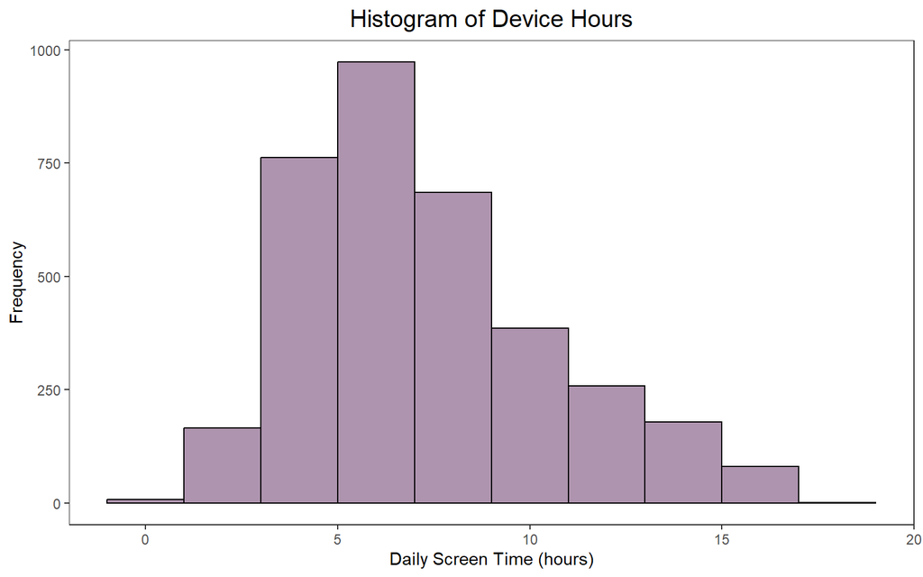

*Figure 1. Device Hours*

##### Moderator Variables

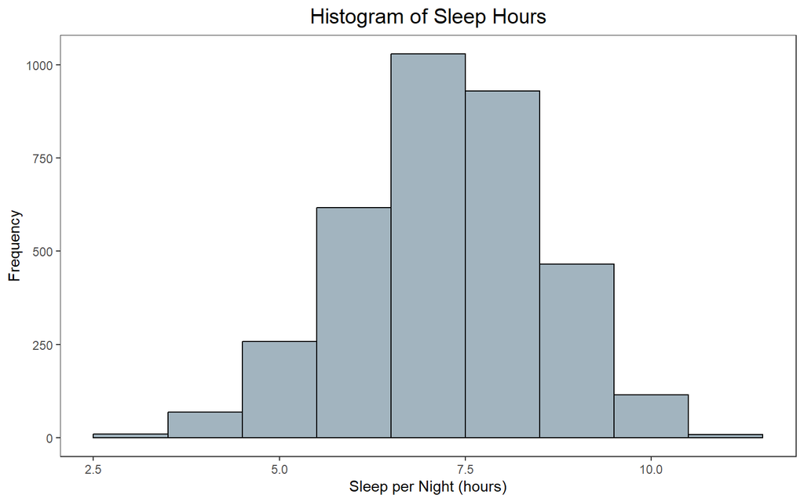

*Figure 2. Sleep Hours*

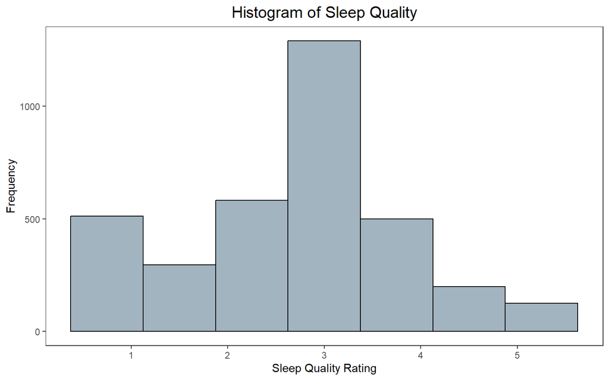

*Figure 3. Sleep Quality*

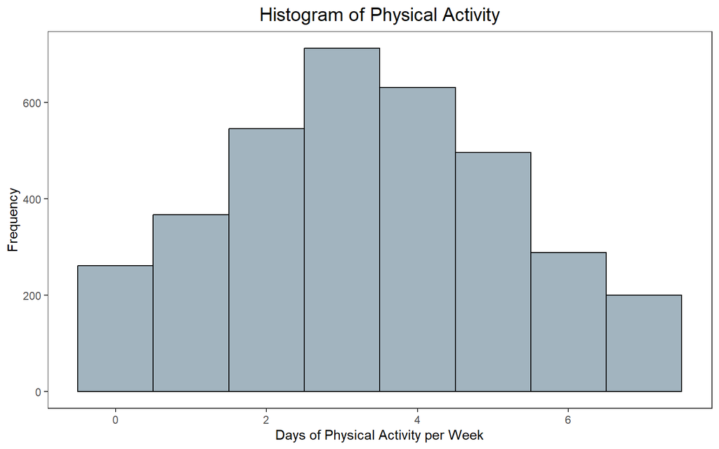

*Figure 4. Physical Activity*

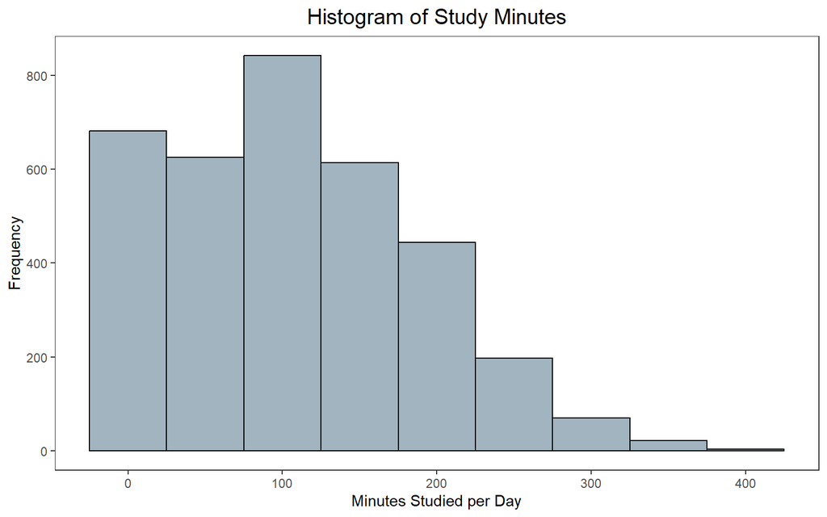

*Figure 5. Study Minutes*

##### Outcome Variables

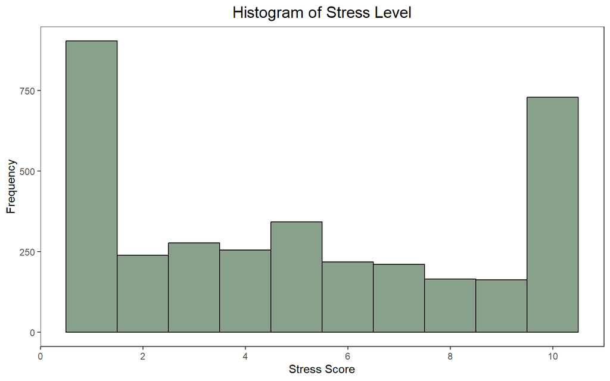

*Figure 6. Stress Level*

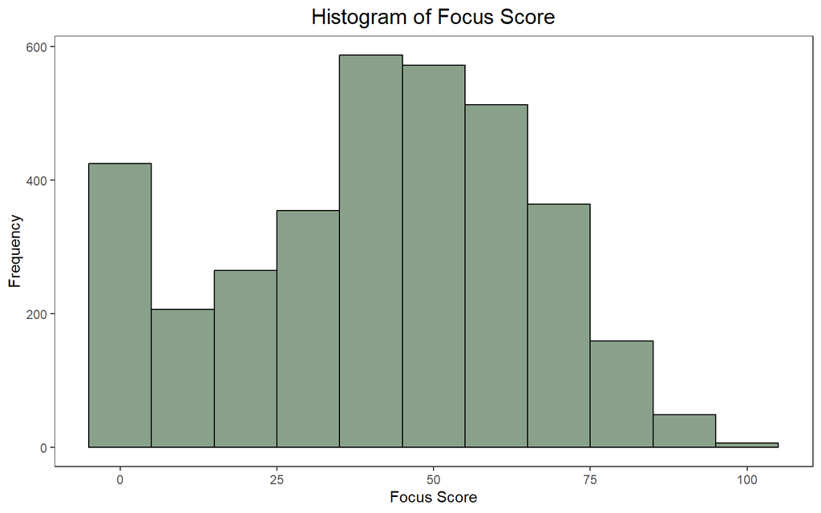

*Figure 7. Focus Score*

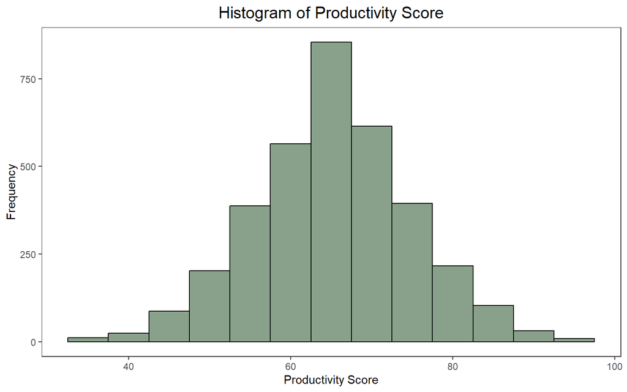

*Figure 8. Productivity Score*

#### Boxplots

##### Predictor Variable

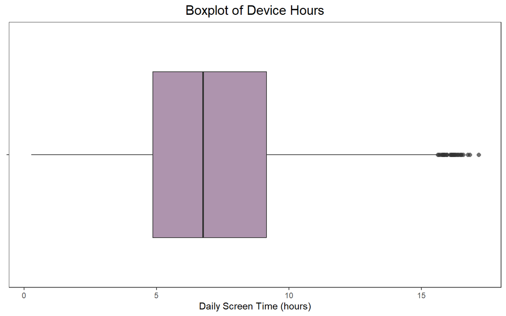

*Figure 9. Device Hours*

##### Moderator Variables

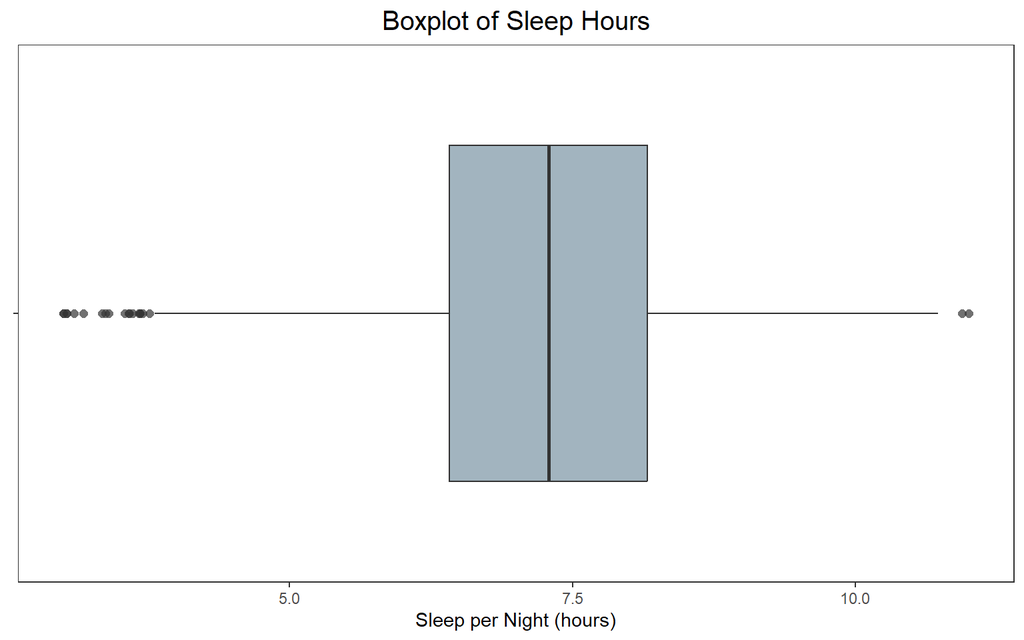

*Figure 10. Sleep Hours*

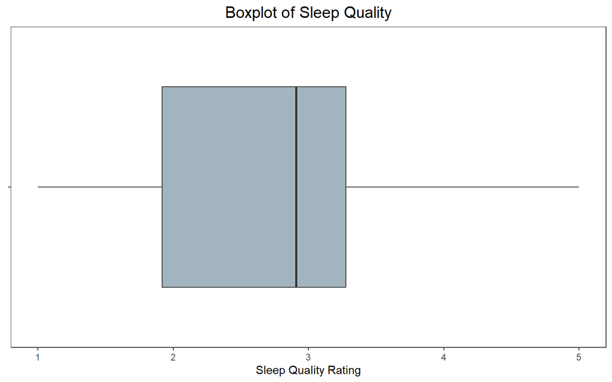

*Figure 11. Sleep Quality*

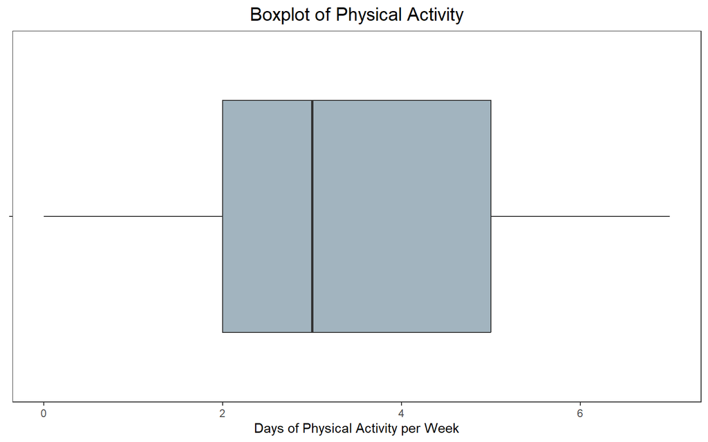

*Figure 12. Physical Activity*

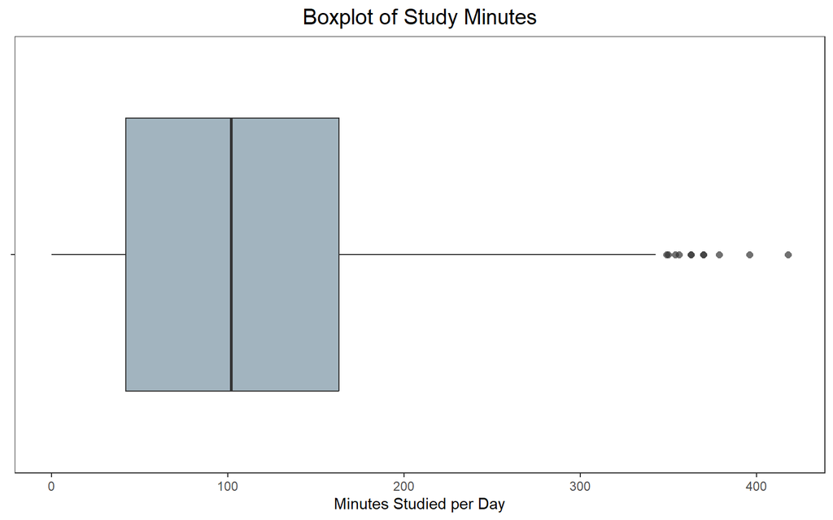

*Figure 13. Study Minutes*

##### Outcome Variables

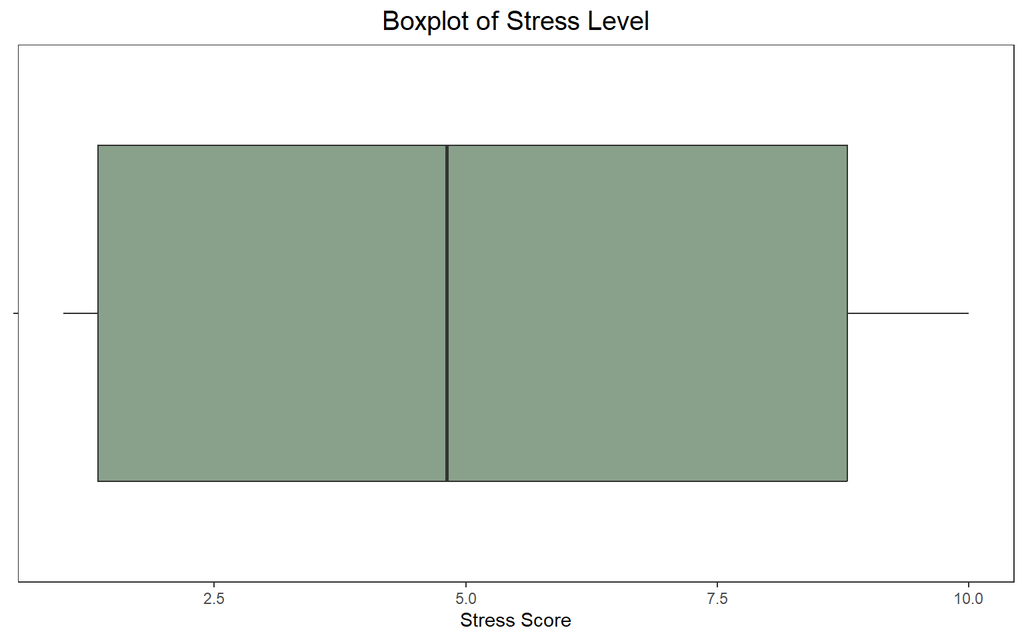

*Figure 14. Stress Level*

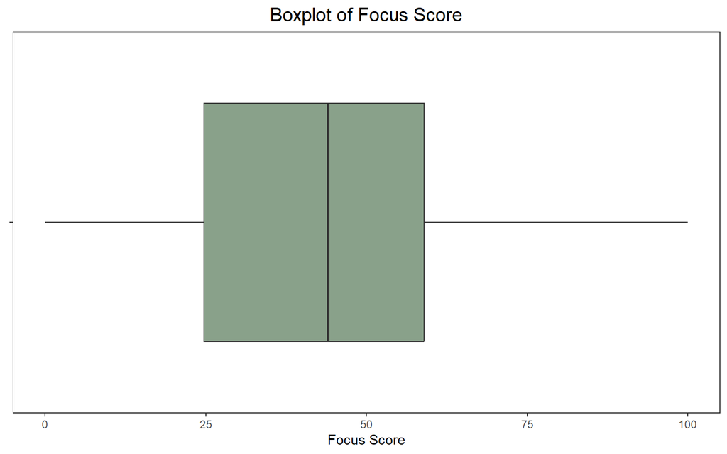

*Figure 15. Focus Score*

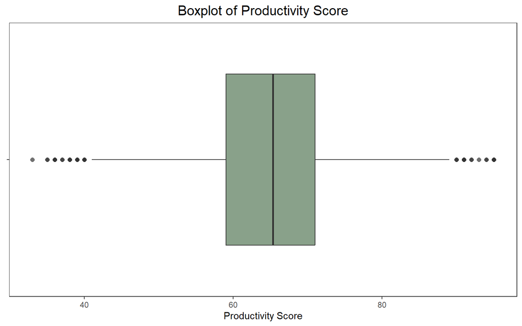

*Figure 16. Productivity Score*

### Correlation Analysis

#### Correlation Matrix

*Table 2* presents Pearson correlation coefficients among screen time, lifestyle balance indicators and mental health and performance outcomes.

Table 2. Correlation Matrix

|  | device_hours_per_day | sleep_hours | physical_activity_days | study_mins | stress_level | focus_score | productivity_score |
| --- | --- | --- | --- | --- | --- | --- | --- |
| device_hours_per_day | 1.00 | -0.59 | -0.01 | -0.01 | 0.32 | -0.03 | 0.09 |
| sleep_hours | -0.59 | 1.00 | 0.04 | 0.00 | -0.29 | 0.03 | -0.03 |
| physical_activity_days | -0.01 | 0.04 | 1.00 | 0.02 | -0.05 | 0.01 | 0.01 |
| study_mins | -0.01 | 0.00 | 0.02 | 1.00 | 0.00 | -0.03 | 0.00 |
| stress_level | 0.32 | -0.29 | -0.05 | 0.00 | 1.00 | -0.14 | 0.03 |
| focus_score | -0.03 | 0.03 | 0.01 | -0.03 | -0.14 | 1.00 | -0.02 |
| productivity_score | 0.09 | -0.03 | 0.01 | 0.00 | 0.03 | -0.02 | 1.00 |

Daily screen time was moderately negatively correlated with sleep duration (r = −0.59), suggesting that individuals with higher device use tended to report fewer hours of sleep. Screen time was also positively associated with stress levels (r = 0.32), indicating that greater digital engagement corresponded with higher perceived stress. Associations between screen time and focus (r = −0.03) and productivity (r = 0.09) were weak.

Sleep duration demonstrated a moderate negative correlation with stress (r = −0.29). Correlations between sleep and focus (r = 0.03) and productivity (r = −0.03) were negligible. Physical activity and study time showed minimal correlations with both screen time and outcome variables.

Importantly, none of the correlations between predictors were sufficiently large to raise immediate concerns regarding multicollinearity.

Notably, a patterned set of associations emerges among screen time, sleep duration and stress. Screen time is negatively related to sleep and positively related to stress, while sleep is inversely associated with stress. Together, these relationships form a pattern of interrelated associations consistent with a potential moderation framework, suggesting that sleep may condition the strength of the relationship between screen time and stress.

Overall, this pattern of associations provides empirical justification for further visual exploration and formal testing of moderation effects in subsequent analyses.

#### Heatmap

*Figure 17* presents a heatmap visualization of the correlation matrix.

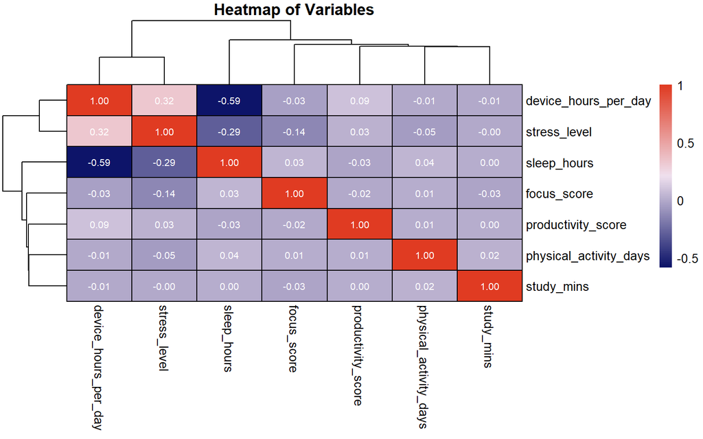

*Figure 17. Heatmap*

Warmer colors indicate positive correlations, whereas cooler colors represent negative associations. The heatmap visually reinforces the moderate inverse association between screen time and sleep, as well as the patterned relationships among screen time, sleep and stress.

### Preliminary Relationship Visualizations

Before testing moderation effects, I visually examined the relationships among screen time, sleep duration and stress levels. These exploratory visualizations help determine whether a triangular pattern exists that would justify testing interaction effects in regression models.

#### Bivariate Relationships Among Screen Time, Sleep & Stress

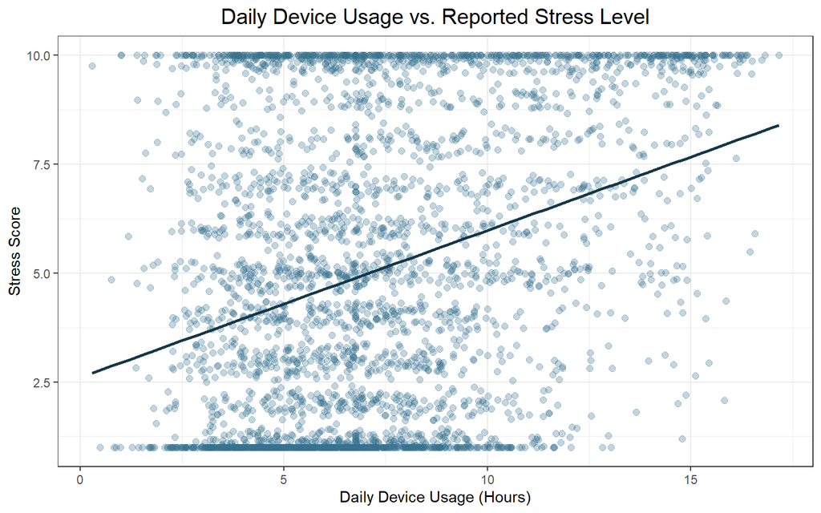

*Figure 18. Daily Screen Time vs. Stress Level*

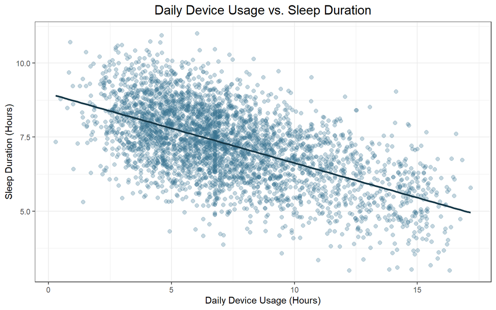

*Figure 19. Daily Screen Time vs. Sleep Duration*

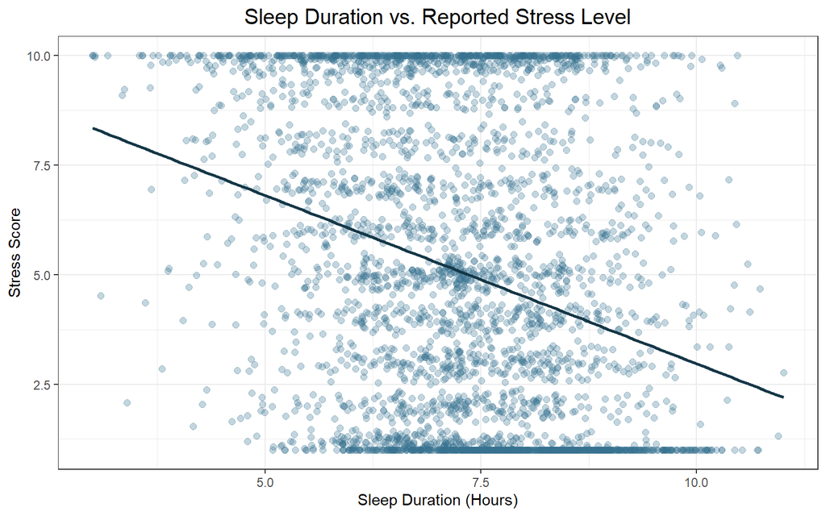

*Figure 20. Sleep Duration vs. Stress Level*

*Figure 18* shows a positive association between *daily screen time* and *stress levels*. As device use increases, reported stress appears to increase as well. The linear trend suggests that higher screen exposure may be associated with elevated psychological strain.

*Figure 19* demonstrates a negative relationship between *screen time* and *sleep duration*. Individuals who report higher device use tend to report fewer hours of sleep. This pattern suggests that sleep may function as a behavioral mechanism linking screen exposure to stress.

*Figure 20* indicates a negative association between *sleep duration* and *stress*. Participants reporting fewer hours of sleep tend to report higher stress levels. This inverse relationship further supports the possibility that sleep plays a moderating role in the association between screen time and stress.

Taken together, Figures 18–20 reveal a a configuration of correlations consistent with conditional effects: screen time is positively associated with stress and negatively associated with sleep, while sleep is negatively associated with stress. This pattern provides conceptual support for examining whether sleep moderates the relationship between screen time and stress.

#### Sleep as a Grouping Variable

To further explore this possibility, sleep duration was divided into high and low groups (median split) and plotted as a grouping variable.

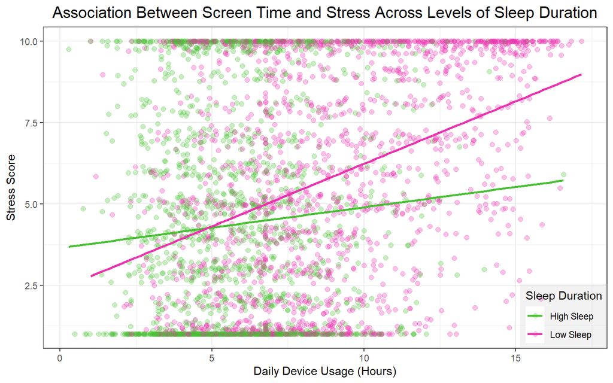

*Figure 21. Association Between Screen Time and Stress Across Levels of Sleep Duration*

*Figure 21* displays the relationship between screen time and stress separately for high and low sleep groups. Visual differences in slope suggest that the strength of the association between screen time and stress may vary depending on sleep duration. This observation warrants formal moderation testing.

## Moderation Analysis

### Overview of Analytical Strategy

To examine whether lifestyle balance moderates the relationship between screen time and mental health outcomes, multiple linear regression models were estimated including interaction terms between mean-centered screen time and each moderator (sleep duration, sleep quality, physical activity and study minutes).

As described in the Data Preparation section, all continuous predictors were mean-centered prior to analysis. Interaction terms between screen time and each moderator variable were computed to test moderation effects.

## Moderation Analysis for Stress

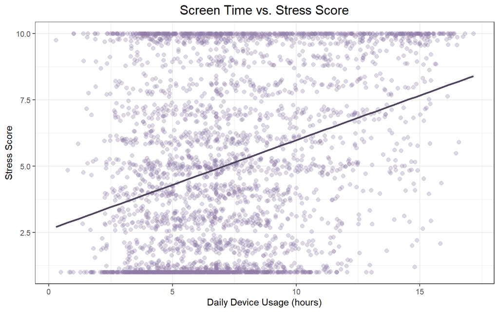

*Figure 22. Screen Time vs. Stress Score*

### Model Specification

To examine whether lifestyle factors moderate the association between screen time and stress, separate linear regression models were estimated for each moderator.

```r
# Baseline Model (Screen Time Only)
sm <- lm(stress_level ~ screen_c, data = data)
# Model 1: Sleep Hours as Moderator
sm1 <- lm(stress_level ~ screen_c * sleep_c, data = data)
# Model 2: Sleep Quality as Moderator
sm2 <- lm(stress_level ~ screen_c * sleepq_c, data = data)
# Model 3: Physical Activity as Moderator
sm3 <- lm(stress_level ~ screen_c * activity_c, data = data)
# Model 4: Study Time as Moderator
sm4 <- lm(stress_level ~ screen_c * study_c, data = data)
# Model 5: Combined Model
sm5 <- lm(stress_level ~
            screen_c * sleep_c +
            screen_c * sleepq_c +
            screen_c * activity_c +
            screen_c * study_c,
          data = data)
```

### Model Fit Statistics

Table 3. Stress Model Prediction Statistics

| Model | r.squared | adj.r.squared | statistic | p.value |
| --- | --- | --- | --- | --- |
| Baseline | 0.1031 | 0.1029 | 402.30 | 8.5e-85 |
| Sleep Hours | 0.1287 | 0.1280 | 172.16 | 4.2e-104 |
| Sleep Quality | 0.1175 | 0.1167 | 155.16 | 2.1e-94 |
| Physical Activity | 0.1053 | 0.1046 | 137.22 | 4.8e-84 |
| Study Time | 0.1032 | 0.1024 | 134.08 | 3.2e-82 |
| Combined Variables | 0.1389 | 0.1367 | 62.55 | 9.0e-107 |

All moderation models predicting stress were statistically significant (all p < 0.001). Among individual moderators, *sleep duration* accounted for the greatest proportion of variance in stress (R² = 0.1287), followed by sleep quality (R² = 0.1175), physical activity (R² = 0.1053) and study time (R² = 0.1032).

### Interaction Interpretation

Table 4. Stress Model Interaction Table

| Model | estimate | std.error | statistic | p.value |
| --- | --- | --- | --- | --- |
| Baseline (Screen Time) | 0.3374 | 0.0168 | 20.06 | 0.0000 |
| Screen Time x Sleep Hours | -0.0737 | 0.0120 | -6.13 | 0.0000 |
| Screen Time x Sleep Quality | -0.1172 | 0.0159 | -7.35 | 0.0000 |
| Screen Time x Physical Activity | 0.0091 | 0.0088 | 1.03 | 0.3027 |
| Screen Time x Study Time | -0.0001 | 0.0002 | -0.33 | 0.7417 |

Interaction analyses revealed that *sleep-related variables* significantly moderated the association between screen time and stress. The interaction between screen time and sleep duration was statistically significant (β = −0.0737, p < 0.001), indicating that the positive relationship between screen time and stress weakens as sleep duration increases.

Similarly, sleep quality significantly moderated the relationship (β = −0.1172, p < 0.001), suggesting that individuals reporting higher sleep quality experience a reduced association between screen time and stress.

In contrast, the interaction terms for physical activity (p = 0.3027) and study time (p = 0.7417) were not statistically significant, indicating that these factors do not meaningfully alter the relationship between screen time and stress.

### Simple Slopes Analysis

```r
# Load package
library(interactions)

# Run simple slopes analysis using sleep duration and sleep quality at moderators
sim_slopes(sm1, pred = screen_c, modx = sleep_c)
sim_slopes(sm2, pred = screen_c, modx = sleepq_c)
```

Sleep Duration

Sleep Quality

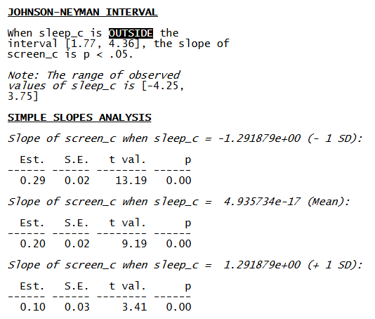

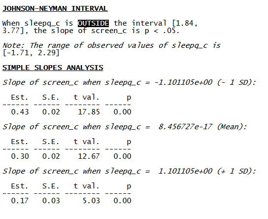

#### **Data Interpretation**

Since the variables were *mean-centered* prior to running the analysis, the results above do not represent the original data values. As a result, the conversion values back to the original data values are reflected below.

**Sleep Duration (Hours)**

The association between screen time and stress was *strongest* among individuals sleeping approximately 6 hours per night (β = 0.29, p <0 .001) and *weakest* among those sleeping approximately 8.5 hours per night (β =0 .10, p < 0.001), indicating that adequate sleep attenuates the relationship between screen exposure and stress.

Furthermore, sleep duration ranged from 3-11 hours in the dataset. Johnson-Neyman analysis indicated that the association between screen time and stress was statistically significant for individuals sleeping less than approximately 9 hours per night. Thus, the analysis indicated that the effect of screen time on stress became non-significant only at very high levels of sleep duration (above ~9 hours per night), suggesting that sufficient sleep substantially buffers the association.

Table 5. Sleep Duration Simple Slopes Analysis

| **Sleep Duration** | **Hours** | **Screen ➝ Stress** |
| --- | --- | --- |
| Low (-1 SD) | ~5.96 hours | 0.29 |
| Average (Mean) | ~7.25 hours | 0.20 |
| High (+1 SD) | ~8.55 hours | 0.10 |

**Johnson-Neyman Interval (adjusted)**: [9.02, 11.61]

**Sleep Quality (0-5)**

The association between screen time and stress was *strongest* among individuals reporting poor sleep quality (approximately 1.6 on the 1–5 scale; β = 0.43, *p* < 0.001) and *weakest* among those reporting high sleep quality (approximately 3.8; β = 0.17, *p* < 0.001), indicating that better perceived sleep quality attenuates the relationship between screen exposure and stress.

Johnson–Neyman analysis indicated that the association remained statistically significant across nearly the entire observed range of sleep quality, becoming non-significant only at very high levels (above approximately 4.55 on the 5-point scale).

Table 6. Sleep Quality Simple Slopes Analysis

| **Sleep Quality** | **Hours** | **Screen ➝ Stress** |
| --- | --- | --- |
| Low (-1 SD) | ~1.61 | 0.43 |
| Average (Mean) | ~2.71 | 0.30 |
| High (+1 SD) | ~3.81 | 0.17 |

**Johnson-Neyman Interval (adjusted)**: [4.55, 6.48]

**Comparison of Models**

Although both sleep duration and sleep quality attenuated the positive association between screen time and stress, sleep quality exhibited a more pronounced moderating effect. The reduction in slope across levels of sleep quality (Δβ = 0.26) exceeded that observed for sleep duration (Δβ = 0.19), suggesting that subjective sleep restoration may be more critical than total sleep time in mitigating the psychological impact of screen exposure. These findings imply that qualitative aspects of sleep may serve as a stronger resilience factor against technology-related stress than sleep quantity alone.

### Interaction Plots

To further examine the moderating effects of sleep duration and sleep quality on the relationship between screen time and stress, interaction plots were generated. These figures illustrate the simple slopes of screen time predicting stress at low (-1SD), mean and high (+1SD) levels of each moderator. Because all predictors were mean-centered prior to analysis, the value of zero represents the sample mean for each variable.

**Sleep Duration**

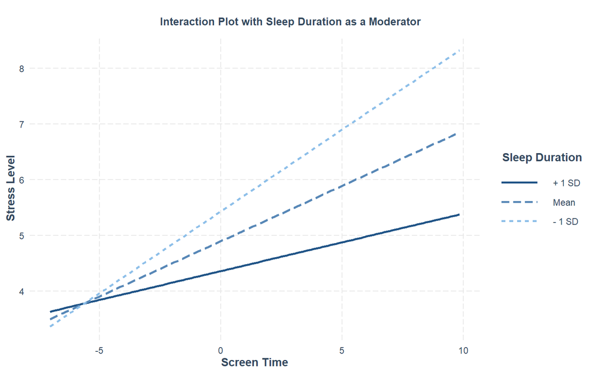

*Figure 23. Sleep Duration Interaction Plot*

As shown in *Figure 23*, the relationship between screen time and stress was positive at all levels of sleep duration. However, the strength of this association varied across levels of sleep. The slope was steepest at low sleep duration (~6 hours per night), indicating that individuals who slept less experienced stronger increases in stress as screen time increased. In contrast, the slope was substantially flatter at high sleep duration (~8.5 hours), suggesting that adequate sleep attenuated the association between screen exposure and stress. These findings support the hypothesis that sleep duration serves as a buffering factor in the relationship between screen time and psychological stress.

**Sleep Quality**

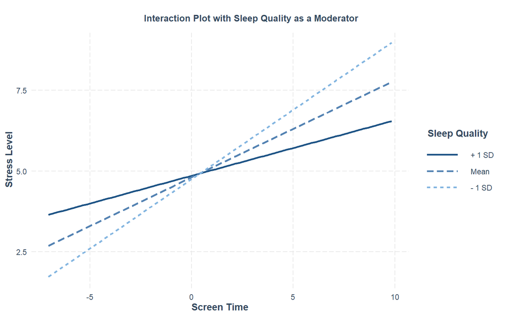

*Figure 24. Sleep Quality Interaction Plot*

### Summary of Moderation Findings

Taken together, both sleep duration and sleep quality moderated the association between screen time and stress, with higher levels of sleep associated with weaker relationships between screen exposure and stress. Notably, the attenuation effect appeared stronger for sleep quality than sleep duration, suggesting that perceived restfulness may be more critical than total sleep time in buffering against screen-related stress. These visual patterns align with the simple slopes and Johnson–Neyman analyses reported above.

## Moderation Analysis for Focus

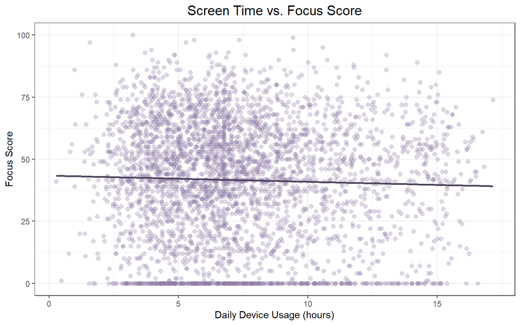

*Figure 25. Screen Time vs. Focus Score*

### Model Specification

To examine whether lifestyle factors moderate the association between screen time and focus scores, separate linear regression models were estimated for each moderator.

```r
# Baseline (Screen Time Only)
fm <- lm(focus_score ~ screen_c, data = data)
# Model 1: Sleep Hours as Moderator
fm1 <- lm(focus_score ~ screen_c * sleep_c, data = data)
# Model 2: Sleep Quality as Moderator
fm2 <- lm(focus_score ~ screen_c * sleepq_c, data = data)
# Model 3: Physical Activity as Moderator
fm3 <- lm(focus_score ~ screen_c * activity_c, data = data)
# Model 4: Study Time as Moderator
fm4 <- lm(focus_score ~ screen_c * study_c, data = data)
# Model 5: Combined Model
fm5 <- lm(focus_score ~
            screen_c * sleep_c +
            screen_c * sleepq_c +
            screen_c * activity_c +
            screen_c * study_c,
          data = data)
```

### Model Fit Statistics

Table 7. Focus Model Prediction Statistics

| Model | r.squared | adj.r.squared | statistic | p.value |
| --- | --- | --- | --- | --- |
| Baseline | 0.0011 | 0.0009 | 4.02 | 0.0451 |
| Sleep Hours | 0.0015 | 0.0006 | 1.72 | 0.1601 |
| Sleep Quality | 0.0016 | 0.0007 | 1.84 | 0.1377 |
| Physical Activity | 0.0012 | 0.0003 | 1.40 | 0.2407 |
| Study Time | 0.0021 | 0.0013 | 2.51 | 0.0573 |
| Combined Variables | 0.0030 | 0.0004 | 1.15 | 0.3247 |

Unlike the stress models, the focus models demonstrated negligible explanatory power. Across all moderation specifications, R² values remained below 0.003, indicating that less than 0.3% of variance in focus was accounted for by screen time and the proposed moderators. Although the baseline model reached statistical significance (p = 0.045), the effect size was negligible (R² = 0.0011), and no moderation effects were observed.

### Interaction Interpretation

Table 8. Focus Model Interaction Table

| Model | estimate | std.error | statistic | p.value |
| --- | --- | --- | --- | --- |
| Baseline (Screen Time) | -0.2484 | 0.1240 | -2.00 | 0.0451 |
| Screen Time x Sleep Hours | -0.0295 | 0.0898 | -0.33 | 0.7423 |
| Screen Time x Sleep Quality | 0.0639 | 0.1184 | 0.54 | 0.5897 |
| Screen Time x Physical Activity | 0.0158 | 0.0652 | 0.24 | 0.8084 |
| Screen Time x Study Time | -0.0001 | 0.0016 | -0.04 | 0.9651 |

To determine whether lifestyle variables moderated the association between screen time and focus, interaction terms were entered into separate regression models for sleep duration, sleep quality, physical activity and study time. *Table 8* presents the parameter estimates for each interaction term. Across all models, the interaction effects were small in magnitude and statistically non-significant, indicating no evidence of moderation.

### Summary of Moderation Findings

Moderation analyses were conducted to examine whether sleep duration, sleep quality, physical activity or study time influenced the relationship between screen time and focus. None of the interaction terms were statistically significant (all p > 0.58), and the models explained negligible variance in focus (R² ≤ 0.003). These findings indicate that the proposed lifestyle variables do not moderate the association between screen time and focus within this sample.

## Moderation Analysis for Productivity

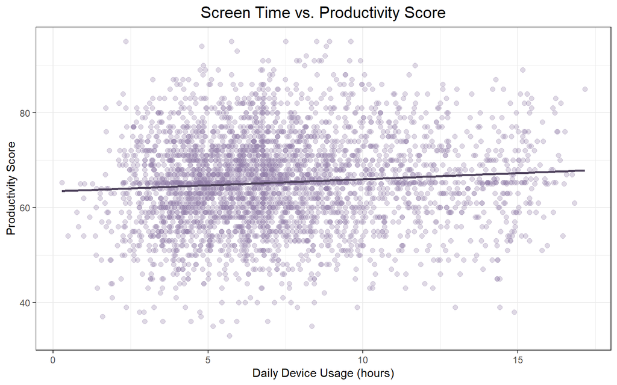

*Figure 26. Screen Time vs. Productivity Score*

### Model Specification

To examine whether lifestyle factors moderate the association between screen time and productivity, separate linear regression models were estimated for each moderator.

```r
# Baseline Model (Screen Time Only)
pm <- lm(productivity_score ~ screen_c, data = data)
# Model 1: Sleep Hours as Moderator
pm1 <- lm(productivity_score ~ screen_c * sleep_c, data = data)
# Model 2: Sleep Quality as Moderator
pm2 <- lm(productivity_score ~ screen_c * sleepq_c, data = data)
# Model 3: Physical Activity as Moderator
pm3 <- lm(productivity_score ~ screen_c * activity_c, data = data)
# Model 4: Study Time as Moderator
pm4 <- lm(productivity_score ~ screen_c * study_c, data = data)
# Model 5: Combined Model
pm5 <- lm(productivity_score ~
            screen_c * sleep_c +
            screen_c * sleepq_c +
            screen_c * activity_c +
            screen_c * study_c,
          data = data)
```

### Model Fit Statistics

Table 9. Productivity Model Prediction Statistics

| Model | r.squared | adj.r.squared | statistic | p.value |
| --- | --- | --- | --- | --- |
| Baseline | 0.0075 | 0.0072 | 26.26 | 3.1e-07 |
| Sleep Hours | 0.0098 | 0.0089 | 11.50 | 1.7e-07 |
| Sleep Quality | 0.0156 | 0.0148 | 18.52 | 6.5e-12 |
| Physical Activity | 0.0083 | 0.0074 | 9.71 | 2.2e-06 |
| Study Time | 0.0075 | 0.0066 | 8.78 | 8.5e-06 |
| Combined Variables | 0.0174 | 0.0148 | 6.86 | 7.7e-10 |

A baseline regression model indicated that screen time significantly predicted productivity, R² = 0.0075, p < 0.001, explaining approximately 0.75% of the variance. When lifestyle variables were added, overall model fit remained statistically significant across specifications (all p < 0.001), with R² values ranging from 0.0075 to 0.0174. Although the inclusion of sleep quality and the combined variables modestly increased explained variance, these changes were small in magnitude. Because moderation is determined by the statistical significance of interaction terms, these model fit statistics are reported for completeness but do not, on their own, indicate the presence of moderation effects.

### Interaction Interpretation

Table 10. Productivity Model Interaction Table

| Model | estimate | std.error | statistic | p.value |
| --- | --- | --- | --- | --- |
| Baseline (Screen Time) | 0.2575 | 0.0502 | 5.12 | 0.0000 |
| Screen Time x Sleep Hours | 0.0881 | 0.0364 | 2.42 | 0.0155 |
| Screen Time x Sleep Quality | 0.1558 | 0.0478 | 3.26 | 0.0011 |
| Screen Time x Physical Activity | 0.0428 | 0.0264 | 1.62 | 0.1057 |
| Screen Time x Study Time | 0.0001 | 0.0006 | 0.12 | 0.9032 |

Moderation analyses were conducted to examine whether lifestyle variables altered the relationship between screen time and productivity. Interaction effects indicated that sleep duration (β = 0.0881, p = 0.0155) and sleep quality (β = 0.1558, p = 0.0011) significantly moderated this relationship. Specifically, the strength of the association between screen time and productivity varied as a function of sleep-related factors. In contrast, physical activity (p = 0.1057) and study time (p = 0.9032) did not significantly moderate the relationship.

### Simple Slopes Analysis

```r
# Load package
library(interactions)

# Run simple slopes analysis using sleep duration and sleep quality at moderators
sim_slopes(pm1, pred = screen_c, modx = sleep_c)
sim_slopes(pm2, pred = screen_c, modx = sleepq_c)
```

Sleep Duration

Sleep Quality

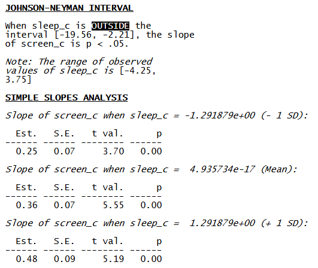

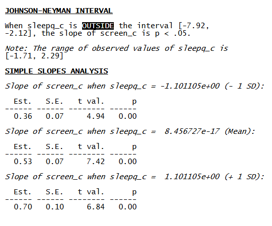

#### **Data Interpretation**

Since the variables were *mean-centered* prior to running the analysis, the results above do not represent the original data values. As a result, the conversion values back to the original data values are reflected below.

**Sleep Duration (Hours)**

As shown in *Table 11*, the relationship between screen time and productivity strengthened as sleep duration increased. This pattern indicates that sleep duration amplifies the association between screen time and productivity. In other words, as sleep increases, the effects of screen time on productivity become stronger.

Johnson-Neyman analysis indicated that the relationship between screen time and productivity is statistically significant when individuals sleep more than ~5.04 hours per night. Given that the observed sleep range in the sample was 3-11 hours, the screen time-productivity association was significant for nearly all typical sleep levels except at extremely low sleep durations.

Overall, these findings suggest that sleep duration significantly moderates the relationship between screen time and productivity. Rather than weakening the association, higher sleep duration strengthens the positive effect of screen time on productivity. Individuals who sleep more appear to translate screen use into productive outcomes more effectively than those who sleep less.

Table 11. Sleep Duration Simple Slopes Analysis

| **Sleep Duration** | **Hours** | **Screen ➝ Productivity** |
| --- | --- | --- |
| Low (-1 SD) | ~5.96 hours | 0.25 |
| Average (Mean) | ~7.25 hours | 0.36 |
| High (+1 SD) | ~8.55 hours | 0.48 |

**Johnson-Neyman Interval (adjusted)**: [-12.31, 5.04]

**Sleep Quality (0-5)**

Simple slopes analysis indicated that sleep quality significantly moderated the relationship between screen time and productivity. As depicted in *Table 12*, higher sleep quality amplifies the positive relationship between screen time and productivity. This suggests that individuals with better sleep quality exhibit greater productivity gains associated with increased screen time.

Table 12. Sleep Quality Simple Slopes Analysis

| **Sleep Quality** | **Hours** | **Screen ➝ Productivity** |
| --- | --- | --- |
| Low (-1 SD) | ~1.61 | 0.36 |
| Average (Mean) | ~2.71 | 0.53 |
| High (+1 SD) | ~3.81 | 0.70 |

**Johnson-Neyman Interval (adjusted)**: [-5.21, 0.59]

**Comparison of Models**

Both sleep duration and sleep quality significantly moderated the relationship between screen time and productivity. However, sleep quality demonstrated a stronger moderating effect, as indicated by greater changes in simple slopes across levels of the moderator (as well as a by a larger interaction coefficient as presented earlier). While the association between screen time and productivity strengthens as sleep duration increased, this effect was most pronounced at higher levels of sleep quality. Additionally, Johnson-Neyman analyses indicated that screen time-productivity relationship was significant across the entire observed range of sleep quality, whereas for sleep duration the relationship was only non-significant at extremely low levels of sleep. Together, these findings suggest that sleep quality may play a more robust role than sleep duration in shaping how screen time relates to productivity.

### Interaction Plots

**Sleep Duration**

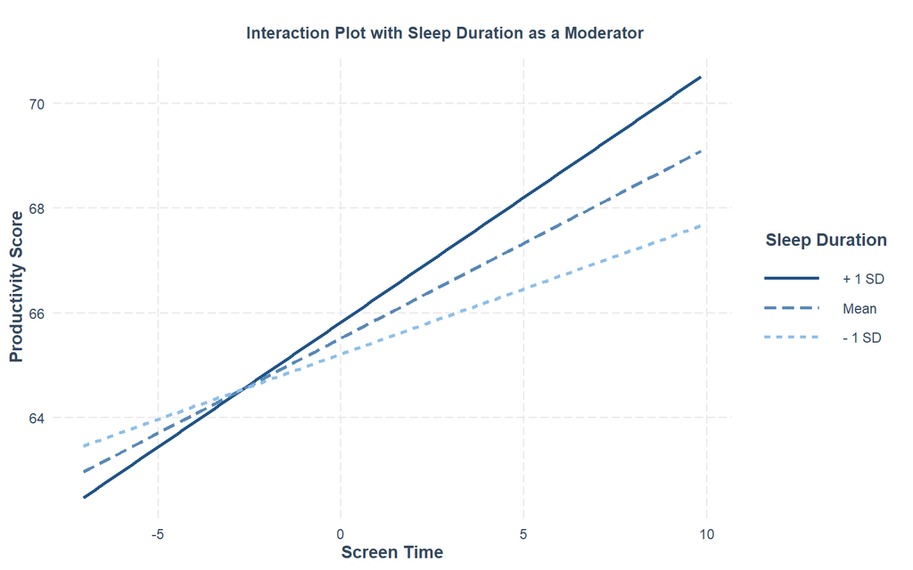

*Figure 27. Sleep Duration Interaction Plot*

As shown in *Figure 27*, the relationship between screen time and productivity is positive at all levels of sleep duration. However, the strength of this association varied across levels of sleep. The slope was steepest at high sleep duration (~8.5 hours per night), indicating that individuals who slept longer experienced stronger increase in productivity as screen time also increased. In contrast, the slope was substantially flatter at low sleep duration (~6 hours), suggesting that low sleep weakened the association between screen exposure and productivity levels. These findings support the hypothesis that sleep duration strengthens the positive relationship between screen time and productivity rather than buffering it.

**Sleep Quality**

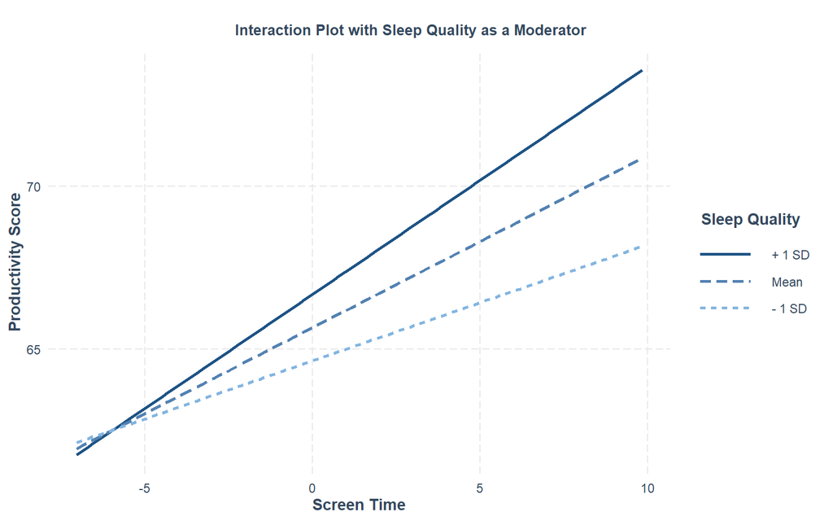

*Figure 28. Sleep Quality Interaction Plot*

A similar but more pronounced pattern emerged for sleep quality in *Figure 28*. The association between screen time and productivity was strongest among individuals reporting high sleep quality and weakest among those reporting low sleep quality. Although the slope remained positive across all levels, the increase in magnitude from low to high sleep quality was substantial, indicating a stronger moderating effect compared to sleep duration. These findings suggest that subjective sleep quality plays an important amplifying role in shaping how screen time relates to productivity, with higher-quality sleep strengthening the positive association between digital engagement and productive functioning.

### Summary of Moderation Findings

Taken together, these findings indicate that sleep functions as a meaningful contextual factor in the relationship between screen time and productivity. While screen time was positively associated with productivity overall, this relationship was amplified among individuals who reported longer and higher-quality sleep. Notably, sleep quality emerged as the stronger moderator, suggesting that subjective restfulness may be more influential than sleep quantity in enhancing the productivity-related benefits of screen engagement.

## Comparative Analysis Across Outcome Variables

To better understand how lifestyle balance conditions the psychological effects of screen time, moderation results were compared across three outcome variables: stress, focus and productivity.

### Differential Sensitivity to Screen Time

For **stress**, screen time demonstrated a moderate positive association that was significantly moderated by both sleep duration and sleep quality. Higher levels of sleep weakened the association between screen exposure and stress, indicating a buffering effect. Sleep quality exhibited the strongest moderating influence, suggesting that subjective restfulness plays a critical role in mitigating technology-related psychological strain.

In contrast, **focus** scores showed negligible associations with screen time and no evidence of moderation by any lifestyle variable. Across all models, variance explained remained below 0.3%, and interaction effects were statistically non-significant. This suggests that screen time may not meaningfully influence attentional functioning within this dataset, or that focus may be shaped by other unmeasured cognitive or environmental factors.

For **productivity**, the pattern diverged from stress. Screen time was positively associated with productivity, and this relationship was amplified, rather than attenuated, by higher sleep duration and sleep quality. Sleep did not buffer the effect but instead strengthened the positive association between digital engagement and perceived productivity.

### Cross-Outcome Pattern

Taken together, the findings suggest that sleep functions as a contextual amplifier of digital effects rather than a uniformly protective factor. Specifically:

- For *stress ➙* sleep buffers harmful associations.
- For *productivity ➙* sleep amplifies beneficial associations.
- For *focus ➙* no meaningful moderation observed.

This divergence indicates that digital engagement may operate through distinct psychological pathways depending on the outcome considered. Screen time appears more strongly related to emotional strain (stress) and performance perceptions (productivity) than to attentional capacity (focus).

Importantly, sleep quality consistently demonstrated stronger moderating effects than sleep duration across outcomes, reinforcing the importance of subjective restorative experience over sleep quantity alone.

## Extended Statistical Analysis

### Standardized Moderation Models

To facilitate comparison of moderation effects across outcome variables, additional models were estimated using standardized predictors and outcomes. Standardization allows regression coefficients to be interpreted in standard deviation units, enabling direct comparison of interaction magnitudes across stress, focus and productivity models.

```r
# Standardize key variables
data_std <- data %>%
  mutate(across(c(device_hours_per_day,
                  sleep_hours,
                  sleep_quality,
                  stress_level,
                  focus_score,
                  productivity_score),
                scale))

# Stress Models
stress_sleep_std <- lm(
  stress_level ~ device_hours_per_day * sleep_hours,
  data = data_std
)

stress_sleepq_std <- lm(
  stress_level ~ device_hours_per_day * sleep_quality,
  data = data_std
)

# Focus Models
focus_sleep_std <- lm(
  focus_score ~ device_hours_per_day * sleep_hours,
  data = data_std
)

focus_sleepq_std <- lm(
  focus_score ~ device_hours_per_day * sleep_quality,
  data = data_std
)

# Productivity Models
productivity_sleep_std <- lm(
  productivity_score ~ device_hours_per_day * sleep_hours,
  data = data_std
)

productivity_sleepq_std <- lm(
  productivity_score ~ device_hours_per_day * sleep_quality,
  data = data_std
)
```

| Outcome | Sleep Duration Interaction (B_std) | Sleep Quality Interaction (B_std) |
| --- | --- | --- |
| Stress | -0.0906 | -0.1229 |
| Focus | -0.0052 | 0.0096 |
| Productivity | 0.0381 | 0.0575 |

In contrast, moderation effects for *focus* were negligible (β = -0.0052 for sleep duration and β = 0.0096 for sleep quality), indicating that neither sleep variable meaningfully altered the relationship between screen time and focus when examined on a standardized scale.

For *productivity,* interaction effects were small and positive (β = 0.0381 for sleep duration and β = 0.0575 for sleep quality). These coefficients suggest that higher sleep quality and longer sleep duration slightly strengthened the association between screen time and productivity. However, the magnitudes were modest relative to the stress models, indicating that moderation effects were comparatively weaker for productivity outcomes.

Overall, standardized comparisons reveal that moderation effects were most pronounced for stress, minimal for focus and modest for productivity. Across outcomes, sleep quality consistently demonstrated slightly stronger interaction effects than sleep duration, reinforcing the importance of subjective sleep experience in shaping behavioral outcomes associated with screen exposure.

### Incremental Variance Explained by Interaction Terms (△R²)

#### Hierarchical Model Comparison Strategy

To evaluate whether interaction terms meaningfully improved model fit, hierarchical regression analyses were conducted. For each outcome variable, Model 1 included only the main effects of screen time and the respective sleep variable. Model 2 added the interaction term. Incremental variance explained (△R²) was calculated as the difference in R² between the two models. This approach isolates the unique contribution of moderation beyond additive effects.

#### △R² Results Across Outcomes

| Outcome | Sleep_Duration_Delta_R2 | Sleep_Quality_Delta_R2 |
| --- | --- | --- |
| Stress | 0.0094 | 0.0136 |
| Focus | 0.0000 | 0.0001 |
| Productivity | 0.0017 | 0.0030 |

#### Cross-Outcome Comparison

Comparison of incremental variance estimates revealed clear differences in practical contribution of moderation effects across outcomes. Interaction terms accounted for the greatest additional variance in *stress*, with sleep quality producing the largest improvement in model fit (△R² = 0.0136), followed by sleep duration (△R² = 0.0094). Although modest in magnitude, these increases indicate that moderation meaningfully enhanced explanatory power for stress beyond additive effects alone.

In contrast, △R² values for *focus* were effectively zero (△R² = 0.0000 for sleep duration and △R² = 0.0001 for sleep quality), indicating that interaction terms provided no meaningful improvement in prediction. This finding suggests that the relationship between screen time and focus operates largely independently of sleep-based moderation.

For *productivity*, interaction effects contributed small but positive increments in explained variance (△R²= 0.0017 for sleep duration and △R² = 0.0030 for sleep quality). While these effects were stronger than those observed for focus, they remained substantially smaller than those for stress, indicating comparatively weaker moderation.

Across all outcomes, sleep quality consistently produced larger △R² values than sleep duration, reinforcing prior standardized analyses suggesting that subjective sleep experience exerts a stronger moderating influence than objective sleep duration.

Overall, hierarchical model comparisons demonstrate that moderation effects were most substantively meaningful for stress, negligible for focus and modest for productivity. These findings suggest that sleep-based buffering mechanisms may be particularly relevant for stress-related outcomes rather than cognitive or performance-related domains.